# Butte Creek

Sadie Gill, Mark Tompkins

December 13, 2018

## Instream Spawning and Rearing Habiat

**Data Source:** [FWS and 2008 FERC relicensing of DeSabla](https://s3-us-west-2.amazonaws.com/cvpiahabitat-r-package/cvpia-sit-model-inputs/DeSabla2008ButteIFIM.pdf)

Units are in square feet.

Adult trout data used for steelhead

Rearing habitat is inn the same sheet in cells A71:D101. Units are square feet per 1000 ft.

### Spawning WUA

#### Spawning WUA Plot

The following plot shows the weighted usable spawning area in square feet per thousand feet of river for Fall Run Chinook Salmon. These area per length rates are multiplied by the total spawning reach length mapped by the SIT.

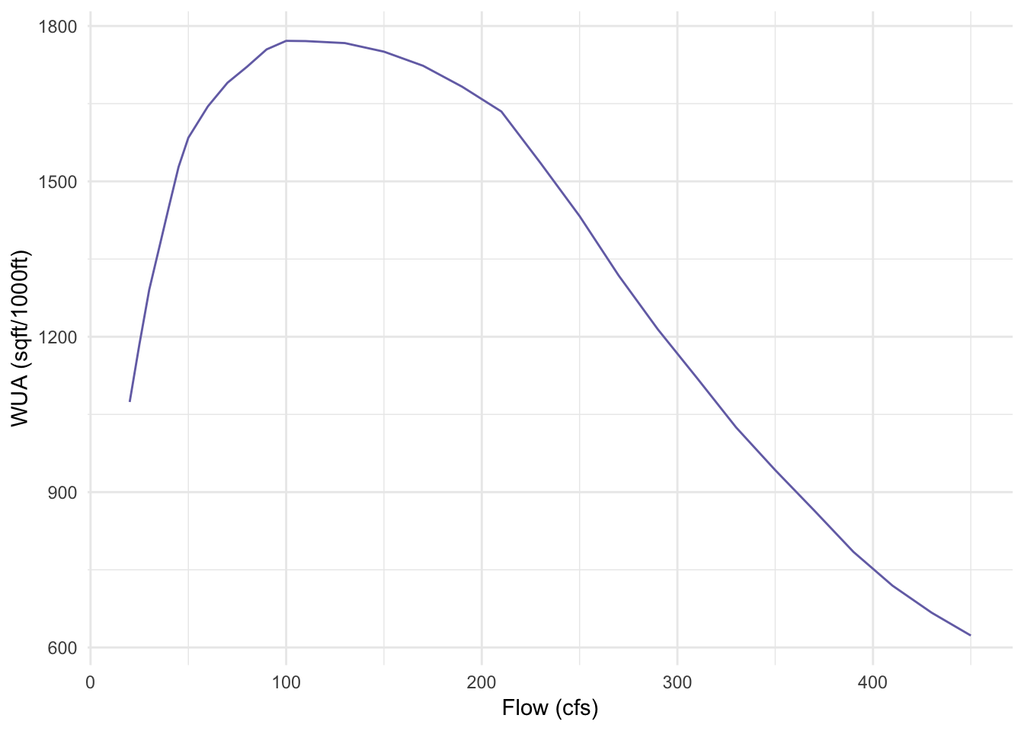

### Rearing WUA

The fry and juvenile instream rearing habitat weighted usable areas for Fall Run Chinook Salmon in the Butte Creek provided by Mark Gard (see ‘~/cvpiaHabitat/data-raw/mark_gard_data/IFIMWUA.xlsx’).

#### Rearing WUA Plot

The following plot shows the weighted usable rearing area in square feet per thousand feet of river for Fall Run Chinook Salmon fry and juvenile. These rates are multiplied by the total rearing reach length mapped by the SIT.

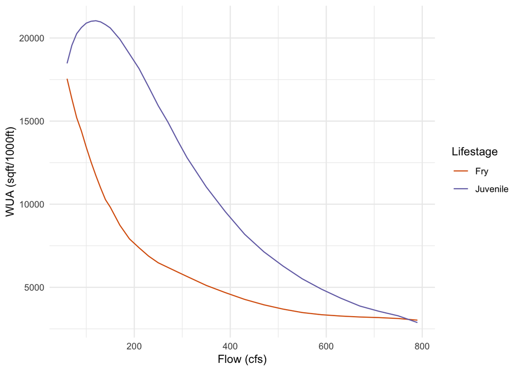